# 6 Distributions de probabilités

## 6.9 Urne contenant plusieurs catégories d’objets

Supposons une urne contenant 12 balles rouges, 18 balles bleues et 10 balles vertes, pour un total de 40 balles. On peut dès lors définir plusieurs problèmes dont les solutions ne seront jamais en contradiction avec la définition que nous avons donnée d’une probabilité.

- Quelle est la probabilité, en tirant de l’urne 5 balles, d’obtenir uniquement des balles rouges?
  - Solution:
    - Puisqu’il y a 12 balles rouges dans l’urne, le nombre de combinaisons résultant en 5 balles rouges sera:

$$C(12,5) = \frac{12!}{5!(12-5)!} = \frac{12\cdot...\cdot8}{5\cdot4\cdot3\cdot2\cdot1} = nE =792$$

```
    -   Le nombre total de combinaisons de 5 balles tirées de
        l'ensemble des 40 balles que contient l'urne est:
```

$$C(40,5) = \frac{40!}{5!(40-5)!} = nS = 658,008$$

```
    -   La probabilité recherchée est donc:
```

$$\frac{nE}{nS} = \frac{792}{658,008} = 0.0012$$

Sous R, on peut définir des fonctions susceptibles de nous fournir une visualisation de ce type de problème. Par exemple, supposons une urne avec une boule de chacune des couleurs rouge, bleue et noire. Si vous choisissez deux boules **avec remise**, il y a $3^2$ permutations :

```
{rouge, rouge}, {rouge, bleu}, {rouge, noir},
{bleu, rouge},  {bleu, bleu},  {bleu, noir},
{noir, rouge},  {noir, bleu},  {noir, noir}.
```

Sous R, on peut obtenir ce résultat en utilisant la fonction **permutations()**, incluse dans la librairie **arrangements**. Cette fonction accepte 3 arguments: le vecteur contenant les éléments à permuter, le nombre d’éléments à sélectionner, et un indicateur logique indiquant la remise ou non:

```r
  x <- c("rouge", "bleu", "vert")   # Définition de l'urne
  # Choisir 2 boules avec remise, et dresser la liste des permutations
  arrangements::permutations(x,
                             2,
                             replace=TRUE)
```

```
#>       [,1]    [,2]
#>  [1,] "rouge" "rouge"
#>  [2,] "rouge" "bleu"
#>  [3,] "rouge" "vert"
#>  [4,] "bleu"  "rouge"
#>  [5,] "bleu"  "bleu"
#>  [6,] "bleu"  "vert"
#>  [7,] "vert"  "rouge"
#>  [8,] "vert"  "bleu"
#>  [9,] "vert"  "vert"
```

À partir de cette liste, il suffit de définir l’événement recherché, en déterminer la fréquence, pour ensuite obtenir sa probabilité. Par exemple, quelle est la probabilité d’obtenir une boule rouge et une boule verte?

```r
x <- c('rouge', 'bleu', 'vert')

res  <-  arrangements::permutations(x,
                                    2,
                                    replace=TRUE)
prob  <-  sum((res[,1]=="rouge" & res[,2]=="vert")|
                (res[,1]=="vert" & res[,2]=="rouge")) / length(x)^2
cat("Probabilité = ",prob)
```

```
#> Probabilité =  0.2222222
```

La fonction **polyurn()** (Listing 6.2) permet d’effectuer ce type de calculs de manière plus générale, par simulation. Les arguments sont:  
- *n* = nombre de balles à sélectionner,  
- *r* = nombre de balles rouges,  
- *b* = nombre de balles bleues,  
- *g* = nombre de balles vertes,  
- *repl* = valeur logique déterminant si l’échantillonnage se fait avec ou sans remise.

La valeur retournée est un vecteur composé des nombres de balles rouges, vertes et bleues, respectivement, dans un échantillon de *n* balles.

```r
x = polyUrn(5, r=12, b=18, g=10)
x
```

```
#> [1] 2 2 1
```

Le premier élément du vecteur sortant est le nombre de balles rouges; le second élément est le nombre de balles bleues; et le dernier élément est le nombre de balles vertes. On peut utiliser cette fonction de manière répétitive un grand nombre de fois pour permettre une estimation des probabilités recherchées.

```r
ndraw <- 100000  # Nombre d'expériences aléatoires
n <- 5         # Nombre de balles tirées lors d'une expérience
r <- 12        # Nombre de balles rouges
b <- 18        # Nombre de balles bleues
g <- 10        # Nombre de balles vertes
E <- c(5,0,0)  # Événement recherché (r = 5, b = 0, g = 0)
repl <- FALSE
succes <- 0
i <- 0
repeat{
  draw <- polyUrn(n,r,b,g,repl) # Exécution d'une expérience
  i <- i + 1
  if(sum(draw==E)==3){succes=succes+1}    # Est-ce un 'succès'?
  if (i == ndraw){break}                  # Exercice complété?
}
cat("Probabilité = ",succes/ndraw)
```

```
#> Probabilité =  0.00119
```

Ce résultat n’est pas très éloigné de ce qu’on a obtenu en utilisant une approche classique!

Relancez le code R précédent en variant le nombre d’expériences. Quelle probabilité obtenez-vous en effectuant 1000, 1,0000, 100,000, 1 million, ou même 10 millions d’expériences, si vous en avez le temps! Quelle conclusion tirez-vous de cet exercice?

### 6.9.1 Exercice 10

Pour les exercices suivants, utilisez l’approche classique et la simulation pour obtenir les réponses:

1. Sous le balcon de Juliette, Roméo cueille des fleurs pour lui lancer un bouquet. Le parterre de roses (la fleur) comporte 4 fleurs rouges, 3 fleurs jaunes et 5 fleurs roses. Roméo procédant dans l’obscurité, il ne peut pas contrôler la couleur des fleurs qui est donc considérée comme aléatoire.
- Si Roméo cueille trois fleurs, quelle est la probabilité qu’il obtienne trois fleurs de couleur rose ?
- Si Roméo cueille trois fleurs, quelle est la probabilité qu’il obtienne une fleur de chaque couleur ?
- Si Roméo cueille quatre fleurs, quelle est la probabilité qu’il n’obtienne aucune fleur jaune ?
- Si Roméo cueille deux fleurs, quelle est la probabilité qu’il obtienne des fleurs de couleurs différentes ?
2. En utilisant la fonction polyUrn() et le code définis plus haut, étudiez une situation dans laquelle l’urne contient 15 balles rouges, 7 balles bleues et 20 balles vertes. Répétez les exercices en variant le nombre d’expériences aléatoires.

**NOTE**: Pour ces exercices, il vous sera nécessaire d’éditer le code R de manière à définir le contexte de l’expérience (nombre de balles à échantillonner, nombre d’expériences, nombres de balles pour chaque couleur), et l’événement recherché. Cela se fait aux lignes suivantes:

```r
ndraw=100000  # Nombre d'expériences aléatoires (tirage de balles)
n <- 5         # Nombre de balles tirées lors d'une expérience
r <- 12        # Nombre de balles rouges
b <- 18        # Nombre de balles bleues
g <- 10        # Nombre de balles vertes
E <- c(5,0,0)  # Événement recherché (r = 5, b = 0, g = 0)
```

- Quelle est la probabilité, en tirant 10 balles, que cet échantillon soit composé de 3 balles rouges, 4 balles bleues et 3 balles vertes?
- Quelle est la probabilité, en tirant 10 balles, que cet échantillon soit composé de 2 balles rouges, d’aucune balle bleue et de 8 balles vertes?
- Quelle est la probabilité qu’un échantillon de 12 balles ne soit composé que de balles vertes?
3. De la même manière qu’en (2), refaites l’examen des probabilités obtenues en (1), sous le balcon de Juliette…

## 6.10 La distribution hypergéométrique multivariée

La distribution **hypergéométrique** ne peut s’appliquer que lorsque deux catégories sont présentes au niveau de la population (eg une urne contenant des balles rouges et des balles bleues; un cabinet composé d’avocats détenant une maîtrise ou un doctorat). Pour couvrir les situations décrites dans le paragraphe précédent, c’est-à-dire lorsque le nombre de catégories est supérieur à 2, une simple expansion de la fonction hypergéométrique peut s’appliquer. On obtient alors la distribution **hypergéométrique multivariée**:

$$P(X_1=x_1,...,X_k=x_k) = \frac{\prod_{i=1}^m {C_{x_i}^{n_i}}} {C_k^N} \tag{6.5}$$

On note que par rapport à la distribution hypergéométrique, le seul ajout consiste à tenir compte de chacune des *k* catégories qui se trouvent dans la population.

Pour illustrer, considérons une urne contenant 8 billes rouges, 3 jaunes et 9 blanches. On sélectionne au hasard 6 billes, sans remise. Quelle est la probabilité de choisir 2 billes rouges, une jaune et 3 blanches?

Puisque la sélection des billes s’effectue dans remise, les résultats observés à chaque sélection de billes dépendent des sélections précédentes. Et puisqu’il y a 3 catégories de billes dans l’urne, la distribution hypergéométrique multivariée est appropriée.

La probabilité recherchée est donc:

$$P(R=2, J=1, B=3) = \frac{{C_2^8}{C_1^3}{C_3^9}}{C_6^{20}}=0.182$$

La librairie **extraDistr** contient une fonction, **dmvhyper()**, permettant ce type de calcul. Les arguments de cette fonction sont:

- x : vecteur contenant les nombres cibles pour chaque catégorie
- n : vecteur contenant l’effectif de chacune des catégories
- k : taille de la sélection

Pour l’exemple précédent, on obtient:

```r
library(extraDistr)
x <- c(2,1,3) # nombres ciblés: 2 billes rouges, une jaune et 3 bleues
n <- c(8,3,9) # nombres de billes: 8 rouges, 3 jaunes et 9 bleues
k <- 6        # on tire 6 billes de l'urne
cat("P(R=2, J=1, B=3) = ", dmvhyper(x,n,k))
```

```
#> P(R=2, J=1, B=3) =  0.1820433
```

Dans la même librairie, on trouve la fonction **rmvhyper()** qui permet de générer de données suivant la distribution hypergéométrique multivariée. On ajoute alors le paramètre **nn** représentant le nombre d’observations à générer:

```r
nn <- 20
n <- c(8,3,9)
k <- 6
x <- rmvhyper(nn,n,k)
head(x, 20)
```

```
#>       [,1] [,2] [,3]
#>  [1,]    3    2    1
#>  [2,]    2    3    1
#>  [3,]    0    1    5
#>  [4,]    3    1    2
#>  [5,]    2    1    3
#>  [6,]    3    0    3
#>  [7,]    2    1    3
#>  [8,]    4    0    2
#>  [9,]    1    0    5
#> [10,]    3    1    2
#> [11,]    2    1    3
#> [12,]    4    0    2
#> [13,]    2    0    4
#> [14,]    2    1    3
#> [15,]    3    2    1
#> [16,]    2    1    3
#> [17,]    3    0    3
#> [18,]    1    1    4
#> [19,]    2    2    2
#> [20,]    2    0    4
```

Cette dernière fonction permet de simplifier la programmation d’une simulation. Pour l’exemple précédent, il suffirait d’écrire:

```r
ndraw <- 100000
obj <- c(2,1,3) # nombres ciblés: 2 rouges, une jaune et 3 bleues
n <- c(8,3,9) # nombres de billes: 8 rouges, 3 jaunes et 9 bleues
k <- 6        # on tire 6 billes de l'urne
draw <- extraDistr::rmvhyper(ndraw,n,k)
succes <-sum(rowSums(t(apply(draw,1,function(x) x==obj)))==3)
cat("P(R=2, J=1, B=3) = ",succes/ndraw)
```

```
#> P(R=2, J=1, B=3) =  0.18165
```

Ce résultat confirme celui obtenu en utilisant l’approche analytique classique.

## 6.11 La distribution de Poisson

On ne pourrait conclure ce chapitre sans faire mention de la distribution de Poisson qui, comme les distributions binomiale, multinomiale, hypergéométrique et hypergéométrique multivariée, concerne un ensemble de données discrètes.

Cette distribution peut s’appliquer lorsque l’on s’intéresse au nombre d’événements se produisant durant une certaine période de temps, ou sur une certaine distance, ou à l’intérieur d’une certaine zone, etc. Par exemple:

- Nombre de crimes survenus à Port-au-Prince durant la première semaine du mois
- Nombre de condamnations prononcées par un juge donné, par mois
- Nombre de buts comptés par l’équipe de Soccer Haïtienne, durant une partie de la Coupe des Amériques
- Nombre de fautes grammaticales par page d’un rapport…

La distribution de probabilités de tels événements n’implique qu’un seul paramètre: le nombre moyen d’événements survenant par intervalle, que l’on identifiera par $\mu$. Formellement, cette distribution est définie par:

$$P(X)=\frac{\mu^X e^{-\mu}}{X!} \tag{6.6}$$

Afin d’illustrer l’utilisation d’une telle fonction, transportons-nous à l’aéroport Toussaint-Louverture de Port-au-Prince, où on estime que le nombre moyen de valises égarées par vol est de 0.3. Quelle est alors la probabilité qu’aucune valise ne soit perdue?

Pour X = 0 et $\mu$= 0.3, on obtient:

$$P(0)=\frac{0.3^0 e^{-0.3}}{0!} = 0.7408$$
Et pour X = 1:

$$P(1)=\frac{0.3^1 e^{-0.3}}{1!} = 0.2222$$
La probabilité qu’il y ait au plus une valise perdue à l’arrivée d’un vol est $0.7408 + 0.2222 = 0.963$

Sous R, les fonctions suivantes sont pertinentes dans ce contexte:

- dpois(x, mu) : Probabilité de l’événement x (scalaire ou vecteur)
- ppois(q, mu, lower.tail = TRUE) : quantile ou vecteur de quantiles pour lesquels on cherche la probabilité cumulative inférieure (ou supérieure)
- qpois(p, mu, lower.tail = TRUE) : Valeur de X sous (ou au-dessus de) laquelle on trouve la probabilité cumulative **p**
- rpois(n, mu) : génération de nombres aléatoires suivant la distribution de Poisson

Pour l’exemple précédent, en utilisant la fonction **dpois()**, on obtient:

```r
x <- 0
mu <- 0.3
cat("P(X=0) = ",
    dpois(0, 0.3))
```

```
#> P(X=0) =  0.7408182
```

On peut également fournir une liste d’événements. Ainsi, quelles sont les probabilités que 0, 1, 2 ou 3 valises soient égarées dans un vol?

```r
x <- c(0,1,2,3)
mu <- 0.3
cat("P(X=0:3) = ",dpois(x, 0.3))
```

```
#> P(X=0:3) =  0.7408182 0.2222455 0.03333682 0.003333682
```

Comme pour les distributions précédentes, le générateur de nombres aléatoires **rpois(n, mu)** permettra de simplifier grandement les simulations qu’on sera amené à réaliser:

```r
x <- rpois(2000, 0.9)
head(x, 20)
```

```
#>  [1] 0 2 2 1 1 0 1 0 0 1 0 2 0 1 1 0 1 0 0 0
```

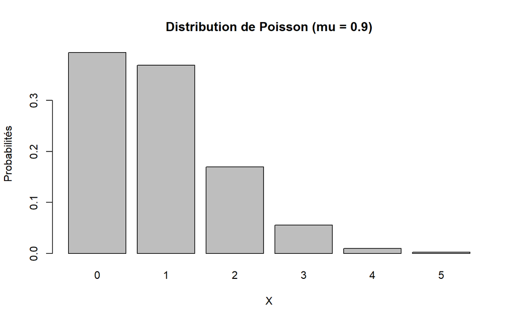

```r
barplot(height = table(factor(x, levels=min(x):max(x)))/length(x),
        ylab = "Probabilités",
        xlab = "X",
        main = "Distribution de Poisson (mu = 0.9)")
```

Le code suivant permettra d’obtenir la probabilité qu’aucune valise ne soit égarée, par voie de simulation:

```r
nrep = 1000000
x <- 0
mu <- 0.3
cat("P(X=0) = ", mean(rpois(nrep, mu)==x))
```

```
#> P(X=0) =  0.739902
```

L’application shiny [POISSON](https://daniel-coulombe.shinyapps.io/Poisson/) permet de manipuler les concepts relatifs à la distribution de Poisson.

## 6.12 Deux Définitions d’une Probabilité…, et une troisième

Dans ce document, deux définitions distinctes du terme PROBABILITÉ ont été mises de l’avant:

1. **Définition classique**, ou **théorique**: Nombre d’événements favorables (résultats d’une épreuve dont on veut déterminer la fréquence relative), **nE** sur le nombre total d’événements possibles (nombre d’éléments dans l’espace échantillonnal), **nS**
2. **Définition fréquentiste**: En répétant une épreuve un GRAND nombre de fois (N) et en notant le résultat de l’épreuve à chaque occasion, on obtient une approximation de P(E) en divisant le nombre de résultats favorables (nE) par le nombre d’épreuves (N). Cette définition se fonde sur la loi des Grands Nombres:

   $$P(E)=\displaystyle \lim_{N \to \infty} \frac{nE}{N}$$

   Lorsque le nombre d’expériences aléatoires tend vers l’infini, la probabilité d’un événement donné est égale au nombre d’occurrences d’un événement particulier, divisé par le nombre d’expérience.

Cette dernière définition nous conviendra dans un très grand nombre de situations qu’on examinera dans le futur. Mais il faut aussi mentionner une troisième définition qui réfère à une approche distincte de l’étude des probabilités et de l’inférence statistique…

3. **Probabilité subjective**: Lorsqu’on ne dispose que peu ou pas de données concernant les résultats d’une expérience aléatoire, on pourra proposer une probabilité subjective, sur la base d’intuition, d’informations partielles ou de toute autre information. On obtient une probabilité exprimant notre de degré de croyance qu’un événement particulier va se produire. Cette probabilité peut varier d’un individu à l’autre, selon les informations dont chacun dispose. Par exemple, d’après la pression atmosphérique présente, le degré d’humidité présent, et la présence de cumulo-nimbus dans le ciel, il y a 60% de chance qu’il y ait de la pluie avant la fin de la journée… La probabilité n’est plus basée sur le nombre d’événements possibles, mais sur l’information dont on dispose pour l’évaluer. Et cette évaluation change en fonction de nouvelles informations s’ajoutant aux anciennes. Cette définition de la probabilité est propre aux méthodes inférentielles Bayesiennes.

## 6.13 CONCLUSION

Dans ce document, nous avons introduit les concepts fondamentaux des probabilités et de leurs distributions. Dans ce contexte, deux approches ont été mises en relief: une approche classique, pertinente lorsque l’espace échantillonnal est fini, de sorte que le nombre d’événements possibles puisse être formellement obtenu; et une approche fréquentiste nécessitant des algorithmes de simulation informatique. Tout au long des documents à suivre, ces notions seront mises en application afin d’étudier une vaste gamme de situations.

Dans un dernier temps, nous avons introduit la version ‘analytique’ ou ‘théorique’ de la distribution de probabilités applicable dans diverses situations impliquant des observations qualitatives ou discrètes:

1. Événements équiprobables:
- la **distribution BINOMIALE**, qui est appropriée pour représenter des données discrètes obtenues lors d’expériences aléatoires dans lesquelles les résultats se présentent sous deux formes: ‘**SUCCÈS** ou **ÉCHEC**: en lançant un dé, on obtient un ’6’ ou on obtient ‘autre chose’; en lançant une pièce de monnaie, on obtient **PILE** ou **FACE**. En écrivant un examen, on le réussit, ou on l’échoue. Cette distribution peut servir de prélude à plusieurs autres distributions de probabilité qui deviendront nécessaires pour traiter des situations plus complexes.
- La **distribution MULTINOMIALE**, appropriée pour représenter des données discrètes obtenues lors d’expériences aléatoires dans lesquelles les résultats se présentent sous plusieurs formes: en lançant un dé régulier, six valeurs différentes peuvent apparaître. Si l’intérêt se porte sur le patron d’observations obtenu en lançant un dé à plusieurs reprises, ou en lançant un certain nombre de dés, alors la Loi Multinômiale s’applique. Ce serait le cas également si le résultat à un examen se traduisait par:
  1. une admission à un programme d’études supérieures
  2. exigence d’une année propédeutique préalable à l’admission à un programme d’études supérieures
  3. mise sur une liste d’attente (admission possible, mais non assurée)
  4. refus d’admission
2. Événements dépendants:
- La **distribution hypergéométrique**, qui s’applique lorsque les résultats d’une expérience aléatoire peuvent prendre deux formes (deux catégories) et sont dépendants des expériences antérieures.
- La **distribution hypergéométrique multivariée**, qui s’applique lorsque les résultats d’une expérience aléatoire peuvent prendre plusieurs formes (plusieurs catégories) et sont dépendants des expériences antérieures.
3. Événements comptabilisés par ‘intervalle’:
- La **distribution de Poisson**, qui s’applique lorsqu’un événement survient à l’intérieur d’une période fixe, ou dans une zone géographique donnée, ou toute autre construit impliquant l’idée d’intervalle (de temps, d’espace, etc.).

Toutes ces distributions permettent le calcul de probabilités ‘théoriques’, par voie analytique. Ces probabilités sont celles que l’on s’attend à obtenir pour un nombre infini d’expériences aléatoires. On peut en obtenir une approximation par voie de simulation informatique.

Un ensemble de distributions de probabilités permettant le même type de calcul, mais pour des événements quantitatifs continus sera présenté dans un chapitre ultérieur.

## 6.14 Solutionnaire des exercices

### 6.14.1 Exercice 1

Pour chacune des situations suivantes, définissez l’expérience aléatoire, l’espace échantillonnal, ce que pourrait être un événement, et calculez nE et nS:

1. Dans un jeu de hasard, on lance 3 pièces de monnaie et on gagne si on obtient 3 FACES ou 3 PILES.
- Solution:
  - L’expérience aléatoire est le **lancer de 3 pièces**
  - L’espace échantillonnal se compose de tous les événements possibles lorsque 3 pièces de monnaie sont lancées: chaque pièce peut tomber sur PILE ou FACE. Donc le nombre d’éléments composant l’espace échantillonnal est égal à $nS=2\times 2\times 2 = 2^3 = 8$
  - Les événements d’intérêt sont: PPP et FFF, et ces deux événements sont uniques à l’intérieur de **S**. Donc nE = 2.
2. Dans une usine, on fabrique 12 instruments par heure. Ces 12 instruments sont ensuite mis en boîte, à la condition qu’il n’y ait pas plus de 2 instruments présentant des défauts de fabrication.
- Solution:
  - L’expérience aléatoire est la constitution d’un ensemble de 12 instruments, chacun d’eux pouvant être défectueux ou non.
  - L’espace échantillonnal se compose de tous les ensembles de 12 instruments qu’il est possible de former, chacun d’eux pouvant être défectueux ou non. Le nombre d’éléments composant cet espace est égal à $nS=2^12^=4096$.
  - Les événements d’intérêt sont les ensembles de 12 instruments comptant 0, 1 ou 2 instruments défectueux. Nous verrons plus loin que nE serait égal au nombre de combinaisons de 12 objets pris 0, puis 1, puis 2 à la fois: $nE=\binom{12}{0}+\binom{12}{1}+\binom{12}{2}=1+12+66=79$
3. Dans une classe de mathématiques, 35 étudiants sont inscrits. Le professeur espère qu’il n’y aura pas plus de 5 étudiants qui échoueront le cours. On suppose ici que pour chacun des étudiants, les chances d’échouer sont de 1/2 (ce qui n’est pas réaliste, mais supposons-le pour les besoins de l’exemple!)
- Solution:
  - L’expérience aléatoire est ‘être inscrit à un cours de mathématiques’.
  - L’espace échantillonnal se compose de nS = 35 étudiants, chacun pouvant échouer ou réussir le cours. Dans ce cas, $nS = 2^35^=34,359,738,370$
  - Les événements d’intérêt sont: observer soit 0, 1, 2, 3, 4 ou 5 échecs. Dans ce cas, $nE = \binom{35}{0}+\binom{35}{1}+\binom{35}{2}+\binom{35}{3}+\binom{35}{4}+\binom{35}{5} =1+35+595+6545+52360+324632=384,168$
4. En période de pandémie, un restaurant ne peut accueillir plus de 5 clients à la fois. À l’extérieur, 15 personnes attendent pour y entrer et on choisit au hasard celles qui sont admises.
- Solution:
  - L’expérience aléatoire est ‘sélectionner 5 personnes attendant à l’extérieur’.
  - L’espace échantillonnal se compose des 15 personnes attendant à l’extérieur. Donc nE = 15.
  - L’événement d’intérêt correspond aux 5 personnes sélectionnées. Dans ce cas, $nE = \binom{15}{5}=3,003$
5. En période de pandémie, un restaurant ne peut accueillir plus de 5 clients à la fois. À l’extérieur, 15 personnes attendent pour y entrer et on choisit au hasard celles qui sont admises Ces 15 personnes portent toutes des noms différents. Désignons-les par les numéros 1 à 15.
- Quelle est la valeur de nE, si on veut admettre les personnes 1 à 5?
  - Solution:
    - Parmi l’ensemble des sélections possibles , il n’y a qu’une manière de sélectionner les clients 1 à 5. nE = 1
- Quelle est la valeur de nS dans cette situation?
  - Solution:
    - De l’exercice 4, on a trouvé nS = 3,003
- Quelle est la probabilité que les personnes 1 à 5 soient admises?
  - Solution:
    - $P(E)=\frac{nE}{nS}=\frac{1}{3003}=0.000333$
6. De combien de façons différentes peut—on répartir un groupe de 7 personnes sur une rangée de 7 chaises ?
- Solution:
  - 7 personnes peuvent prendre la première chaise; il reste 6 personnes pour la deuxième, 5 pour la troisième, etc. Donc il y a 7! = 5040 manières d’assoir 7 personnes dans une rangée de 7 chaises.
7. Trois garçons et deux filles prennent place sur un banc public de 5 places:
- De combien de façons différentes, 3 garçons et 2 filles peuvent-ils prendre place sur ce banc?
  - Solution:
    - Cinq personnes peuvent prendre place de 5! = 120 manières, sur un banc de 5 places.
- De combien de façons peuvent-ils s’asseoir si les garçons s’assoient les uns à côté des autres et s’il en est de même pour les filles ?
  - Solution:
    - Si les garçons et les filles sont groupés, on obtient soit ‘GGGFF’ ou ‘FFGGG’. Donc il y a 2 façons d’obtenir cet arrangement.
- De combien de manières différentes peuvent—ils s’asseoir si seulement les filles s’assoient l’une à côté de l’autre?
  - Solution:
    - Dans ce cas, les arrangements possibles sont: ‘GFFGG’, ‘GGFFG’. Donc deux arrangements possibles.

### 6.14.2 Exercice 2

1. Un comité de 3 personnes doit être formé à partir d’un groupe de 12 employés d’un grand commerce. Une des 3 personnes sélectionnées sera présidente du comité, une autre sera secrétaire, et l’autre agira comme conseillère.
1. Combien de comités différents sont possibles?

```
- Solution:
  - Puisqu'un rôle particulier est donné à chaque personne composant un comité, on doit tenir compte de l'ordre. Le nombre de PERMUTATIONS de 12 personnes prises 3 à la fois est donc:
  $$P(12,3) =   \frac{12!}{(12-3)!} = 12\cdot11\cdot10=1320$$
```

2. En supposant que les 12 employés du commerce portent des noms différents, combien de comités seraient composés de ‘Marie-Lune’, ‘Pierre’, et ‘Harold’?
   - Solution:
   - Ces trois personnes forment un comité, et chacune d’elles prend un des 3 rôles. Le nombre de permutations de trois personnes prises 3 à la fois est égal à 6: 3 personnes peuvent occuper le poste de président. Une fois ce poste comblé, il reste 2 personnes pour les postes de secrétaire et de conseiller. Et finalement, la troisième personne prend le dernier poste: P(3,3)=6
3. Quelle est la probabilité que ce dernier événement se produise?
   - Solution:
   - $P(E)=\frac{6}{1320}=0.004545$
4. Si ‘Pierre’ doit nécessairement être Président en raison de son ancienneté dans l’entreprise, dans combien de comités lui associerait-on ‘Marie-Lune’ et ‘Harold’?
   - Solution:
   - Si Pierre est président, deux personnes sont sélectionnées parmi les 11 qui restent disponibles. Le nombre de permutations de 11 personnes prises 2 à la fois est:
     $$P(11,2) = \frac{11!}{(11-2)!} = 11\cdot10=110$$
     De ces 110 possibilités, les événements ‘Marie-Lune est secrétaire’ et ‘Harold est conseiller’, et ‘Marie-Lune est conseillère’ et ‘Harold est secrétaire’ sont les deux seuls événements d’intérêt.

e, Quelle est la probabilité que ce dernier événement se produise?  
- Solution: - $P(E)=\frac{2}{110}=0.01818$

### 6.14.3 Exercice 3

1. De combien de maniéré peut-on former un jury de 3 hommes et 2 femmes parmi 7 hommes et 5 femmes ?
- Solution:
  $$C(7,3) = \frac{7!}{3!(7-3)!} = 35$$
  $$C(5,2) = \frac{5!}{2!(5-2)!} = 10$$
  Le nombre total est le produit: $35\times10=350$ Sous R:

```r
choose(7,3)*choose(5,2)
```

```
#> [1] 350
```

2. À l’occasion d’un examen, un étudiant doit répondre à 8 questions sur un total de 10.
1. Combien de choix de questions sont possibles ?
- Solution:
  - Le nombre de combinaisons de 10 questions prises 8 à la fois:

  ```r
  choose(10,8)
  ```

  ```
  #> [1] 45
  ```

2. Combien de choix y a-t-il s’il doit répondre aux 3 premières questions ?
- Solution:
  - Si les 3 premières questions sont obligatoires, il reste 5 questions à choisir parmi les 7 qui restent:

  ```r
  choose(7,5)
  ```

  ```
  #> [1] 21
  ```

3. Combien de choix y a—t-il s’il doit répondre au moins à 4 des 5 premières questions ?
- Solution:
  - Ici, on doit considérer le choix de 4 questions parmi les 5 premières. Une fois ces 4 questions sélectionnées, il en reste 6 à partir desquelles on doit en choisir 4. Donc, le nombre d’examens différents est:

  ```r
  choose(5,4)*choose(6,4)
  ```

  ```
  #> [1] 75
  ```

3. Combien de plaques d’immatriculation de véhicules peut-on former si chaque plaque contient 2 lettres différentes suivies de 3 chiffres différents ?
- Solution:
  - On doit choisir 2 lettres parmi les 26 que contient l’alphabet, et 3 chiffres parmi les entiers de 0 à 9. Donc, le nombre de plaques d’immatriculation possible est:

  ```r
  choose(26,2)*choose(10,3)
  ```

  ```
  #> [1] 39000
  ```

### 6.14.4 Exercice 4

Considérez le diagramme suivant pour les questions suivantes:

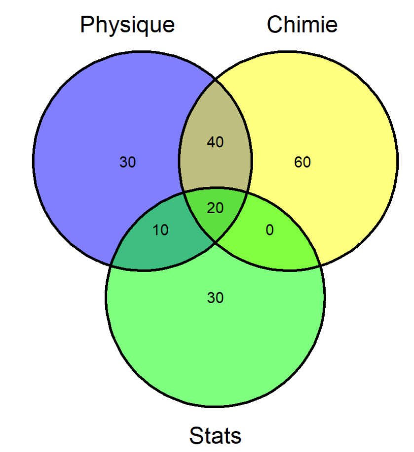

a. Quelle est donc la probabilité qu’un étudiant s’inscrive à un cours de Physique (B), OU à un cours de Chimie (C)? - Solution: - Les événements ne sont pas mutuellement exclusifs. Donc
$$P(B\cup C)=P(B)+P(C)−P(B\cap C)=100/200+120/200−60/200=160/200=0.80$$

$$P(C \cap S)=0.10~~~~P(C)=0.60~~~~P(S)=0.30~~~~~P(C) \times P(S)=0.18$$
Ces deux événements ne sont pas indépendants

### 6.14.5 Exercice 5

1. Déterminez la distribution de fréquence des résultats (nombre de FACES), lorsque le nombre de pièces de monnaie est n = 100, et que les pièces ne sont pas trafiquées (soit p = 0.5).
- Solution:
  - Par simulation, créons la distribution de probabilités du lancer de 100 pièces de monnaie. Répétons l’échantillonnage 10,000 fois:

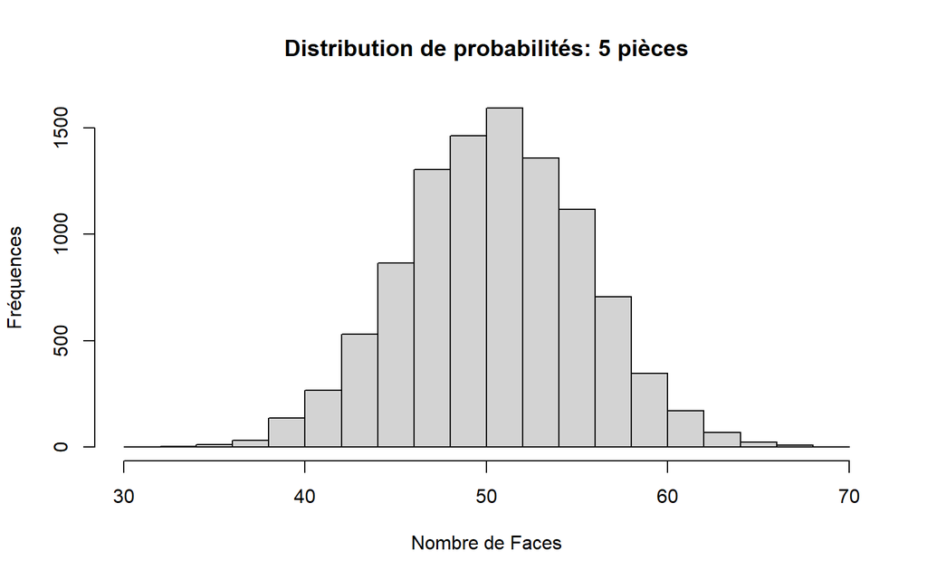

```r
res = vector()    # Initialisation du vecteur des résultats
No_essais = 10000 # Spécification du nombre d'essais à effectuer
for(i in 1:No_essais){
  x = CoinToss(100,0.5)
  res[i] = sum(x=="Face")
}
fr = as.matrix(table(res))
pr = fr[,1] / No_essais
x = sort(unique(res))
tbl = data.frame(x,fr,pr)
espm=sum(x*pr)
colnames(tbl) = c("#Faces","Fréq","Prop")
hist(res+.001,xlab="Nombre de Faces",
     ylab="Fréquences",
     main="Distribution de probabilités: 5 pièces")
```

```r
kable(tbl, booktabs=TRUE,
      caption="Distribution du nombre de Faces",
      row.names=FALSE) %>%
  kable_styling(full_width = FALSE)
```

Distribution du nombre de Faces

| #Faces | Fréq | Prop |
| --- | --- | --- |
| 31 | 1 | 0.0001 |
| 33 | 4 | 0.0004 |
| 34 | 3 | 0.0003 |
| 35 | 10 | 0.0010 |
| 36 | 9 | 0.0009 |
| 37 | 23 | 0.0023 |
| 38 | 54 | 0.0054 |
| 39 | 83 | 0.0083 |
| 40 | 123 | 0.0123 |
| 41 | 145 | 0.0145 |
| 42 | 208 | 0.0208 |
| 43 | 321 | 0.0321 |
| 44 | 401 | 0.0401 |
| 45 | 462 | 0.0462 |
| 46 | 613 | 0.0613 |
| 47 | 690 | 0.0690 |
| 48 | 692 | 0.0692 |
| 49 | 769 | 0.0769 |
| 50 | 825 | 0.0825 |
| 51 | 766 | 0.0766 |
| 52 | 691 | 0.0691 |
| 53 | 666 | 0.0666 |
| 54 | 591 | 0.0591 |
| 55 | 526 | 0.0526 |
| 56 | 378 | 0.0378 |
| 57 | 327 | 0.0327 |
| 58 | 216 | 0.0216 |
| 59 | 131 | 0.0131 |
| 60 | 101 | 0.0101 |
| 61 | 70 | 0.0070 |
| 62 | 44 | 0.0044 |
| 63 | 24 | 0.0024 |
| 64 | 9 | 0.0009 |
| 65 | 14 | 0.0014 |
| 66 | 6 | 0.0006 |
| 67 | 3 | 0.0003 |
| 68 | 1 | 0.0001 |

```r
cat("Espérance mathématique = ",espm)
```

```
#> Espérance mathématique =  49.9617
```

[output not shown]

2. Comment pourriez-vous qualifier la distribution obtenue?
- Elle est symétrique
- les valeurs inférieures à 30 et supérieures à 70 sont très improbables
- Le centre de la distribution semble se trouver autour de 50 FACEs, et de fait, pour cette simulation, l’espérance mathématique est égale à:

```r
espm
```

```
#> [1] 49.9617
```

3. Obtenez la proportion des essais où on obtient plus de 65 FACES, en utilisant le tableau de fréquences.
- Solution:

```r
sum(pr[(x>=65)])/length(x)
```

```
#> [1] 0.00006486486
```

4. Obtenez cette proportion en comptabilisant cette proportion directement des résultats de chaque essai.
- Solution:
  - La variable contenant l’ensemble des résultats obtenus à chaque essai est **res**. Le code R suivant cherche les valeurs de **res** supérieures à 65:

  ```r
  cat("La probabilité d'obtenir 65+ FACEs = ",sum(res>=65)/length(res))
  ```

  ```
  #> La probabilité d'obtenir 65+ FACEs =  0.0024
  ```

5. Pour quelle proportion des essais obtient-on entre 65 et 85 FACES?
- Solution:

```r
cat("La probabilité d'obtenir entre 65 et 85 FACEs = ",
    sum((res>=65)&(res<=85))/length(res))
```

```
#> La probabilité d'obtenir entre 65 et 85 FACEs =  0.0024
```

6. Sous quelle valeur de x (nombre de FACES) trouve-t-on 75% de la distribution?
- Solution:
  - La position de la valeur de x sous laquelle on trouve 75% de la distribution est:

  ```r
  rc75 = round(0.75*length(res),0)
  ```

  - Donc, en ordonnant les scores en ordre croissant, et en trouvant le score occupant cette position, on trouve:

  ```r
  sort(res)[rc75]
  ```

  ```
  #> [1] 53
  ```

7. Au-dessus de quelle valeur de x trouve-t-on 10% de la distribution?
- Solution:
  - De la même manière, en inversant la requête, on cherche la valeur de X sous laquelle se trouve 90% de la distribution:

```r
sort(res)[length(res)*0.9]
```

```
#> [1] 56
```

8. Quelles sont les limites à l’intérieur desquelles on retrouve les 95% centraux des résultats de lancers de ces 100 pièces de monnaie?

```r
sx = sort(res)
liminf = length(res)*.025
limsup = length(res)*0.975
cat("[",sx[liminf]," < X < ",sx[limsup],"] = 95%")
```

```
#> [ 40  < X <  60 ] = 95%
```

### 6.14.6 Exercice 6

1. Déterminez la distribution de fréquence des résultats observés en lançant un dé à 100 reprises, supposant que le dé n’est pas truqué.
- Solution:
  - Le code R permettant la simulation du lancer d’un dé est reproduit ci-dessous:

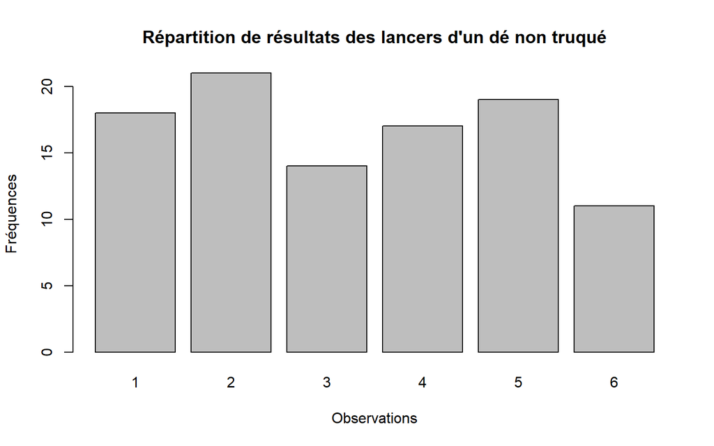

```r
res = vector()  # Initialisation du vecteur des résultats
No_essais = 100  # Spécification du nombre d'essais à effectuer
res = DiceRoll(No_essais)
ft = as.matrix(table(res))
fr = ft/sum(ft)
f = data.frame(sort(unique(res)), ft, fr)
colnames(f) = c("Face", "Freq", "Prop")

barplot(height = f$Freq, names = f$Face, xlab = "Observations",
    ylab = "Fréquences",
    main = "Répartition de résultats des lancers d'un dé non truqué")
```

2. Comment pourriez-vous qualifier la distribution obtenue? A première vue, seriez-vous porté à croire que le dé est truqué?
- Solution:
  - À première vue, il semble que la probabilité d’obtenir un ou l’autre des résultats possibles (1-6) varie. S’il existe une différence suffisamment grande dans ces probabilités, on pourra peut-être croire que le dé est truqué. Mais le nombre de réplications est relativement faible!
3. Répétez l’expérience en lançant le dé 300 fois, puis 1000 fois, et enfin 10,000 fois. Avez-vous des raisons de croire que le dé est truqué?

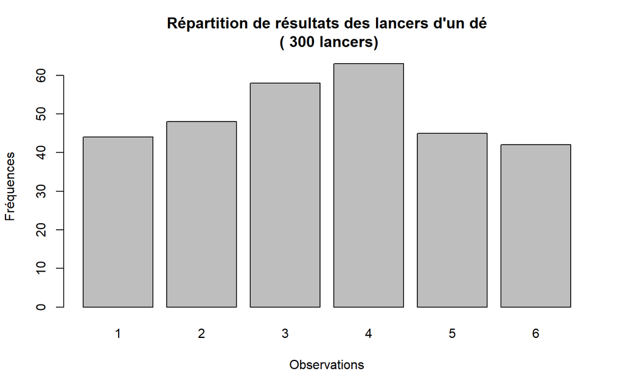

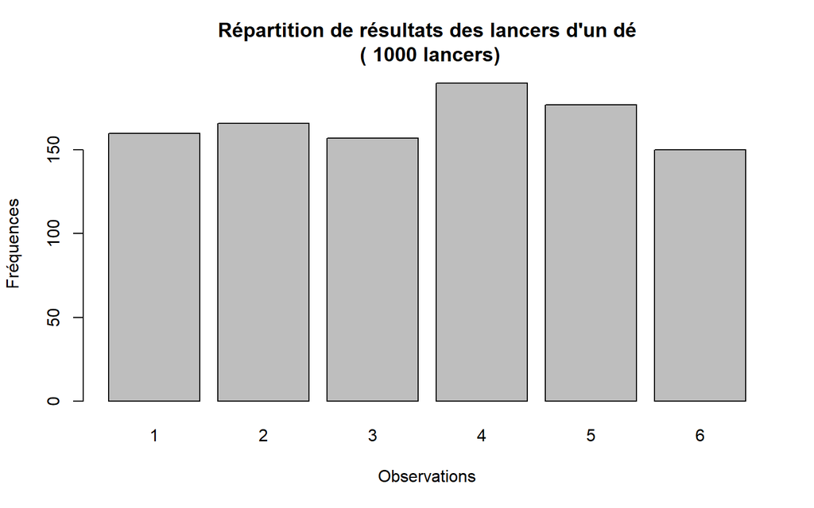

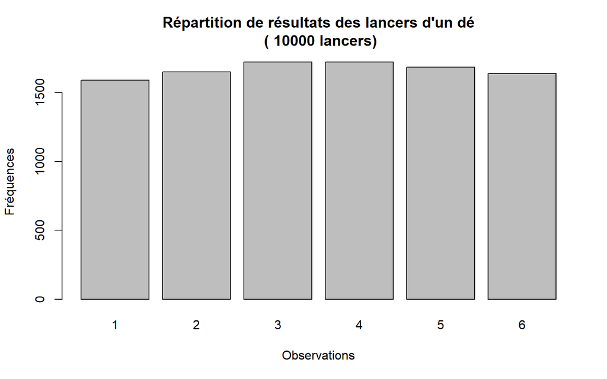

```r
for (i in c(300, 1000, 10000)) {
    res = vector()  # Initialisation du vecteur des résultats
    res = DiceRoll(i)
    Freq = as.matrix(table(res))
    Prop <- Freq / sum(Freq)
    Faces <- sort(unique(res))
    ft = data.frame(Faces, Freq, Prop)
    titl = paste("Répartition de résultats des lancers d'un dé\n (",
        i, "lancers)")
    barplot(height = ft$Freq, names = ft$Faces, xlab = "Observations",
        ylab = "Fréquences", main = titl)
}
```

- Avec un grand nombre de réplications, les différences entre les probabilités d’obtenir une face particulière s’estompent. Il devient de plus en plus difficile de croire que le dé est truqué.
4. Quelle conclusion générale pourriez-vous tirer de ces expériences?
- Solution:
  - La précision des estimations de probabilités augmente avec le nombre de réplications.
5. Exécutez le code R suivant afin de définir un dé trafiqué de manière à ce que la probabilité d’obtenir une des faces du dé (1-6) soit différente de celle typique d’un dé non truqué, et pour obtenir un échantillon initial de 30 lancers de ce dé.